# LBB4

Reynard Verill

January 27, 2021

# Objectives

This report is going to analyze the correlation between the target variable “channel” with the predictor variables , and develop a suitable model for predicting the outcome of channel based on the other known data in terms of binary categorical answer, “yes” or “no”, based on the resulting probability.

# Library and Setup

Importing the necessary libraries for the processing of the wholesale data frame.

```r
library(caret)
library(dplyr)
```

```r
library(gmodels)
library(ggplot2)
library(class)
library(tidyr)
library(GGally)
theme_set(theme_minimal() +
            theme(legend.position = "top"))

options(scipen = 999)
```

# Logistic Regression

## Data Import

Import the data to be analyzed for this report. In this case, the data we utilize is the wholesale data which was obtained from the kaggle website. Apart from that, we also analyze the type of data in each variable of the data frame which we store inside the wholesale variable.

```
## Rows: 440
## Columns: 8
## $ Channel          <int> 2, 2, 2, 1, 2, 2, 2, 2, 1, 2, 2, 2, 2, 2, 2, 1, 2, 1…
## $ Region           <int> 3, 3, 3, 3, 3, 3, 3, 3, 3, 3, 3, 3, 3, 3, 3, 3, 3, 3…
## $ Fresh            <int> 12669, 7057, 6353, 13265, 22615, 9413, 12126, 7579, …
## $ Milk             <int> 9656, 9810, 8808, 1196, 5410, 8259, 3199, 4956, 3648…
## $ Grocery          <int> 7561, 9568, 7684, 4221, 7198, 5126, 6975, 9426, 6192…
## $ Frozen           <int> 214, 1762, 2405, 6404, 3915, 666, 480, 1669, 425, 11…
## $ Detergents_Paper <int> 2674, 3293, 3516, 507, 1777, 1795, 3140, 3321, 1716,…
## $ Delicassen       <int> 1338, 1776, 7844, 1788, 5185, 1451, 545, 2566, 750, …
```

These are the explanation of each variable which was obtained from Kaggle:

Channel -> Hotel/Restaurant/Cafe Region -> Lisnon, Oporto or others (nominal) Fresh -> annual spending (m.u.) on fresh products (Continuous) Milk -> annual spending (m.u.) on milk products (Continuous) Grocery -> annual spending (m.u.)on grocery products (Continuous) Frozen -> annual spending (m.u.)on frozen products (Continuous) Detergent_Papers -> annual spending (m.u.) on detergents and paper products (Continuous) Delicassen -> annual spending (m.u.)on and delicatessen products (Continuous)

## Exploratory Data Analysis

Before making any model for the prediction of data, we need to explore further the types of data that we have in each variable and determine whether they are of the correct type, and check whether there is any null value.

```r
colSums(is.na(wholesale))
```

```
##          Channel           Region            Fresh             Milk
##                0                0                0                0
##          Grocery           Frozen Detergents_Paper       Delicassen
##                0                0                0                0
```

After calling the function above, we are assured that the data is complete. Hence, there is no missing value.

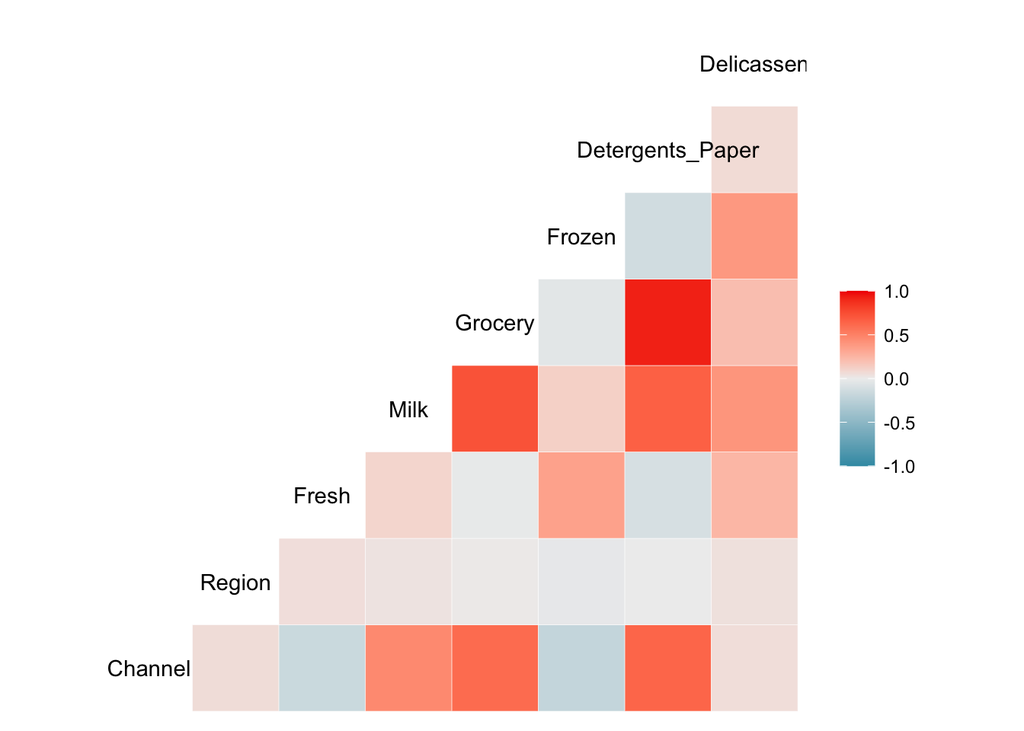

```r
ggcorr(wholesale)
```

From the above chart upon calling the function ggcorr, we can know which variables are highly inter-correlated and not. Apart from that, we also need to dispose of the Region variable as a factor data type would make our analysis more bias due to its discrete value (more suitable for classification model such as naiveBayes and randomForest).

```r
wholesale <- wholesale %>%
    select(-c("Region"))
```

## Sampling

```r
#Set a random number as the seed
set.seed(123)
index <- sample(nrow(wholesale), nrow(wholesale)*0.8)

data_train <- wholesale[index, ]
data_test <-wholesale[-index,]


data_train_glm <- data_train  %>%
  mutate_at("Channel", as.factor)

data_test_glm <- data_test  %>%
  mutate_at("Channel", as.factor)
```

Check the proportion of the channel target variable that we have in our data_train, and determine whether there is a data imbalance or not.

```r
table(as.factor(data_train$Channel))
```

```
##
##   1   2
## 238 114
```

```r
data_train <- data_train %>% mutate_at("Channel", as.factor)
data_train <- upSample(x= data_train %>% select(-c("Channel")),
                         y= data_train$Channel, list = F,
                         yname = "Channel")
table(data_train$Channel)
```

```
##
##   1   2
## 238 238
```

```r
summary(data_train)
```

```
##      Fresh             Milk          Grocery          Frozen
##  Min.   :     3   Min.   :   55   Min.   :    3   Min.   :   25
##  1st Qu.:  2685   1st Qu.: 1897   1st Qu.: 2838   1st Qu.:  657
##  Median :  7832   Median : 4980   Median : 7621   Median : 1311
##  Mean   : 11372   Mean   : 7200   Mean   :10655   Mean   : 2731
##  3rd Qu.: 16117   3rd Qu.: 8421   3rd Qu.:13829   3rd Qu.: 3026
##  Max.   :112151   Max.   :73498   Max.   :92780   Max.   :60869
##  Detergents_Paper   Delicassen    Channel
##  Min.   :    3    Min.   :    3   1:238
##  1st Qu.:  369    1st Qu.:  436   2:238
##  Median : 2512    Median : 1042
##  Mean   : 4178    Mean   : 1646
##  3rd Qu.: 5977    3rd Qu.: 1877
##  Max.   :40827    Max.   :47943
```

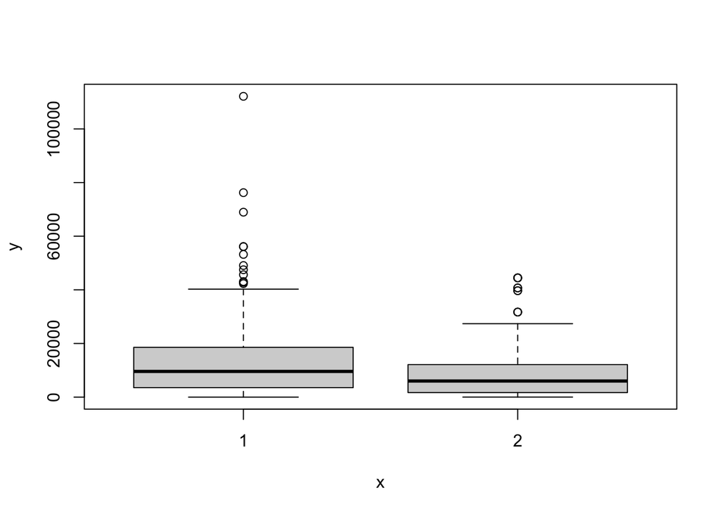

```r
plot(as.factor(data_train$Channel), data_train$Fresh)
```

After examining the outcome of the summary function above, it can be inferred that the distribution of each variable can be quite extreme, and hence, a scaling towards the data frame might be necessary to make the prediction model less bias.

## Data Preprocessing

During this process, we will separate the training data and test data into their x and y components to train and test the model respectively.

```r
train_x <- data_train %>%
  select(-Channel) %>%
  scale()

train_y <- as.factor(data_train$Channel)
```

```r
test_x <- data_test %>%
  select(-Channel) %>%
  scale(center = attr(train_x,"scaled:center"),
  scale = attr(train_x, "scaled:scale")
  )

test_y <- as.factor(data_test$Channel)
```

## Model Fitting

### Using generalized linear model

In this section, we use the generalized linear model to get a sense of how the model would be like when being interpreted as a linear regression of its predictor variables.

```r
model_wholesale <- glm(Channel ~ ., data_train_glm, family = "binomial")
model_step <- step(model_wholesale, direction="both", trace=0)
```

[output not shown]

```r
summary(model_step)
```

```
##
## Call:
## glm(formula = Channel ~ Grocery + Frozen + Detergents_Paper,
##     family = "binomial", data = data_train_glm)
##
## Deviance Residuals:
##      Min        1Q    Median        3Q       Max
## -2.73022  -0.31334  -0.24564   0.05889   2.92052
##
## Coefficients:
##                     Estimate  Std. Error z value             Pr(>|z|)
## (Intercept)      -3.65194182  0.44015412  -8.297 < 0.0000000000000002 ***
## Grocery           0.00013694  0.00005137   2.666              0.00768 **
## Frozen           -0.00010765  0.00007482  -1.439              0.15021
## Detergents_Paper  0.00081344  0.00013624   5.971        0.00000000236 ***
## ---
## Signif. codes:  0 '***' 0.001 '**' 0.01 '*' 0.05 '.' 0.1 ' ' 1
##
## (Dispersion parameter for binomial family taken to be 1)
##
##     Null deviance: 443.34  on 351  degrees of freedom
## Residual deviance: 164.78  on 348  degrees of freedom
## AIC: 172.78
##
## Number of Fisher Scoring iterations: 7
```

```r
pred_train <- predict(model_step, data_train_glm, type="response")
pred_train <- ifelse(pred_train > 0.5, 2, 1) %>% as.factor

confusionMatrix(pred_train, data_train_glm$Channel)
```

```
## Confusion Matrix and Statistics
##
##           Reference
## Prediction   1   2
##          1 225  15
##          2  13  99
##
##                Accuracy : 0.9205
##                  95% CI : (0.8871, 0.9465)
##     No Information Rate : 0.6761
##     P-Value [Acc > NIR] : <0.0000000000000002
##
##                   Kappa : 0.8175
##
##  Mcnemar's Test P-Value : 0.8501
##
##             Sensitivity : 0.9454
##             Specificity : 0.8684
##          Pos Pred Value : 0.9375
##          Neg Pred Value : 0.8839
##              Prevalence : 0.6761
##          Detection Rate : 0.6392
##    Detection Prevalence : 0.6818
##       Balanced Accuracy : 0.9069
##
##        'Positive' Class : 1
##
```

The above is the performance of our model against our data train.

```r
predict_glm <- predict(model_step, data_test_glm, type="response")
predict_glm <- ifelse(predict_glm > 0.5, 2, 1) %>% as.factor
predict_glm
```

```
##  1  2  3  4  5  6  7  8  9 10 11 12 13 14 15 16 17 18 19 20 21 22 23 24 25 26
##  1  2  1  1  2  2  1  1  2  2  2  2  1  2  1  1  2  1  2  1  1  1  1  1  2  2
## 27 28 29 30 31 32 33 34 35 36 37 38 39 40 41 42 43 44 45 46 47 48 49 50 51 52
##  1  1  2  1  1  1  1  1  1  1  1  1  2  1  1  1  1  2  1  1  2  1  1  1  1  1
## 53 54 55 56 57 58 59 60 61 62 63 64 65 66 67 68 69 70 71 72 73 74 75 76 77 78
##  1  1  1  1  1  1  1  1  1  1  2  1  1  1  1  1  1  1  2  1  1  2  1  1  1  1
## 79 80 81 82 83 84 85 86 87 88
##  1  1  1  1  1  2  1  1  1  1
## Levels: 1 2
```

```r
confusionMatrix(predict_glm, data_test_glm$Channel)
```

```
## Confusion Matrix and Statistics
##
##           Reference
## Prediction  1  2
##          1 58 10
##          2  2 18
##
##                Accuracy : 0.8636
##                  95% CI : (0.7739, 0.9275)
##     No Information Rate : 0.6818
##     P-Value [Acc > NIR] : 0.00007429
##
##                   Kappa : 0.6598
##
##  Mcnemar's Test P-Value : 0.04331
##
##             Sensitivity : 0.9667
##             Specificity : 0.6429
##          Pos Pred Value : 0.8529
##          Neg Pred Value : 0.9000
##              Prevalence : 0.6818
##          Detection Rate : 0.6591
##    Detection Prevalence : 0.7727
##       Balanced Accuracy : 0.8048
##
##        'Positive' Class : 1
##
```

### Using K-nearest neighbor

```r
modelknn <- knn3(train_x,
                 train_y,
                 k = sqrt(nrow(train_x)))
predknn <- predict(modelknn, test_x, type="class")
```

```r
predknn <- knn3Train(train_x,
                     test_x,
                     train_y,
                     k = sqrt(nrow(train_x)) %>% round()) %>%
  as.factor()

head(predknn)
```

```
## [1] 2 2 1 1 2 2
## Levels: 1 2
```

```r
confusionMatrix(predknn, test_y)
```

```
## Confusion Matrix and Statistics
##
##           Reference
## Prediction  1  2
##          1 52  3
##          2  8 25
##
##                Accuracy : 0.875
##                  95% CI : (0.7873, 0.9359)
##     No Information Rate : 0.6818
##     P-Value [Acc > NIR] : 0.00002377
##
##                   Kappa : 0.725
##
##  Mcnemar's Test P-Value : 0.2278
##
##             Sensitivity : 0.8667
##             Specificity : 0.8929
##          Pos Pred Value : 0.9455
##          Neg Pred Value : 0.7576
##              Prevalence : 0.6818
##          Detection Rate : 0.5909
##    Detection Prevalence : 0.6250
##       Balanced Accuracy : 0.8798
##
##        'Positive' Class : 1
##
```

By using the K-nearest neighbor algorithm, we are able to obtain a model with lower recall compared to the GLM model, but higher specificity.

## Summary

The objective of the interpretation of this report is highly dependent upon the goal of the reader. It is advised to use the glm, step-wise regression model in order to obtain a higher recall, although there is not a major difference between both models. On the other hand, the K-nearest neighbor model manages to obtain a more accurate metric as a whole as reflected in the specificity and overall accuracy of the outcome of the confusion matrix.